# lab06

Notebook created by Jan Gądek

**Digital Signal Processing Lab**

**Discrete LTI Systems**

**Notebook version:** 1.0

# Introduction

The assignment addresses the topic of discete Linear Time-Invariant systems and their implementations.

## Reading list

Before working with the notebook, you might find it useful to become acquainted with the following materials:

- Section **10.1 Układy dyskretne LTI** from “Cyfrowe przetwarzanie sygnałów : od teorii do zastosowań, WKŁ 2014” by T. P. Zieliński.
- Section **10.2 Algorytm filtracji sygnałow za pomocą dyskretnych układów LTI** from “Cyfrowe przetwarzanie sygnałów : od teorii do zastosowań, WKŁ 2014” by T. P. Zieliński.
- Section **10.3 Transformacja Z** from “Cyfrowe przetwarzanie sygnałów : od teorii do zastosowań, WKŁ 2014” by T. P. Zieliński.
- Section **10.4 Odwrotna transformacja Z** from “Cyfrowe przetwarzanie sygnałów : od teorii do zastosowań, WKŁ 2014” by T. P. Zieliński.
- Section **10.5 Właściwości transformacji Z** from “Cyfrowe przetwarzanie sygnałów : od teorii do zastosowań, WKŁ 2014” by T. P. Zieliński.
- Section **10.6 Transmitancja układów dyskretnych** from “Cyfrowe przetwarzanie sygnałów : od teorii do zastosowań, WKŁ 2014” by T. P. Zieliński.
- Section **13.1 Klasyczne struktury filtrów cyfrowych** from “Cyfrowe przetwarzanie sygnałów : od teorii do zastosowań, WKŁ 2014” by T. P. Zieliński.
- Section **13.4 Splot liniowy i kołowy** from “Cyfrowe przetwarzanie sygnałów : od teorii do zastosowań, WKŁ 2014” by T. P. Zieliński.
- Section **13.5 Algorytmy szybkiego splotu sygnałów dyskretnych** from “Cyfrowe przetwarzanie sygnałów : od teorii do zastosowań, WKŁ 2014” by T. P. Zieliński.
- Section **13.6 Algorytmy sekcjonowanego szybkiego splotu sygnałów dyskretnych** from “Cyfrowe przetwarzanie sygnałów : od teorii do zastosowań, WKŁ 2014” by T. P. Zieliński.

## Notebook setup

```python
# Easy path management
from pathlib import Path

# Time utils
import time

# NumPy package
import numpy as np

# Opening Waveform Audio File Format (*.wav)
from scipy.io import wavfile

# tqdm for displaying nice progress bar
from tqdm.auto import tqdm

# Matplotlib for plotting figures
from matplotlib import pyplot as plt
from matplotlib import patches

# Audio class from ipython for displaying audio player in notebooks
from IPython.display import Audio
```

# Discrete Linear Convolution

Implement [discrete linear convolution](https://en.wikipedia.org/wiki/Convolution#Discrete_convolution) of two discrete signals.

**Discrete linear convolution** $$\large (f \ast g)[n] = \sum_{m=-\infty}^{+\infty} f[n-m]g[m] $$

```python
def linear_conv(f, g):

    N=f.size
    M=g.size
    K=N + M - 1
    y=np.zeros(K)

    for n in range(K):
        for m in range(M):
            if (n-m>=0) and (n-m<N):
                y[n]+=f[n-m]*g[m]

    return y


    """
    This function should compute linear convolution of two signals in the time domain.

    Parameters
    ----------
    f: numpy array of shape (N, )
        A vector containing samples of a signal.
    g: numpy array of shape (M, )
        A vector containing samples of a signal.

    Returns
    -------
    y: numpy array of shape (N+M-1,)
        A vector containing convolution.
    """

    raise NotImplementedError
```

## Verify your implementation

```python
# Do not change anything in the code below

# Generate signal f
f = np.random.randn(np.random.randint(10, 100))

# Generate signal g
g = np.random.randn(np.random.randint(10, 100))

# Compute convolution using your implementation
X = linear_conv(f,g)

# Compute convolution using reference implementation from numpy
X_ref = np.convolve(f,g)

# Error between your implementation and reference implementation
X_err = np.abs(X - X_ref)**2

# RMSE
X_RMSE = np.sqrt(np.mean(X_err))

print('RMSE:', np.round(X_RMSE, 15))
print('Your implementation succeeded' if X_RMSE < 1e-10 else 'That RMSE is a little bit too BIG!')
```

```
RMSE: 0.0
Your implementation succeeded
```

# Discrete circular convolution using DFT

The [Circular convolution theorem](https://en.wikipedia.org/wiki/Discrete_Fourier_transform#Circular_convolution_theorem_and_cross-correlation_theorem) tells us that the convolution of two discrete and time-limited signals corresponds to the multiplication of their DFTs. In previous notebooks, you have learned a highly efficient algorithm for computing the discrete Fourier transform. Because of these algorithms, it is computationally efficient to implement a convolution of two signals by computing the DFTs, multiplying them, and then computing the IDFT.

The `circular_conv` function should calculate circular convolution using DFT. An essential part is to zero-pad the shorter signal to the length of the longer one.

```python
def circular_conv(f,g):
    N=f.size
    M=g.size
    K=max(N,M)
    F=np.fft.fft(f,K)
    G=np.fft.fft(g,K)
    Y=F*G  #conv
    y=np.fft.ifft(Y)
    return y

    """
    This function should compute circular convolution of two signals in the time domain.

    Parameters
    ----------
    f: numpy array of shape (N, )
        A vector containing samples of a signal.
    g: numpy array of shape (M, )
        A vector containing samples of a signal.

    Returns
    -------
    y: numpy array of shape (maximum(N, M),)
        A vector containing convolution.

    """

    raise NotImplementedError
```

## Verify

```
RMSE: 0.0
Your implementation succeeded
```

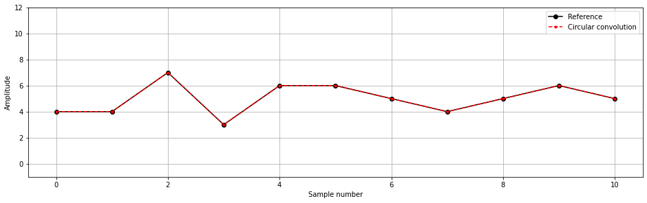

```python
# Create signal f
f = np.array([0, 1, 2, 1, 0, 1, 2, 1, 0, 1, 2])

# Create signal g
g = np.array([0, 1, 0, 3, 0, 1])

# Compute circular convolution
y_c = circular_conv(f, g)

# Reference convolution
y_ref = np.array([4., 4., 7., 3., 6., 6., 5., 4., 5., 6., 5.])

# RMSE
RMSE = np.sqrt(np.mean(np.abs(y_c - y_ref)**2))

print('RMSE:', np.round(RMSE, 15))
print('Your implementation succeeded' if RMSE < 1e-14 else 'That RMSE is a little bit too BIG!')

plt.figure(figsize = (16,10))
plt.subplot(2,1,1)
plt.plot(y_ref, "ko-", label="Reference")
plt.plot(y_c, "r.--", label="Circular convolution")

plt.xlabel('Sample number')
plt.ylabel('Amplitude')
plt.legend()
plt.ylim([-1, 12])
plt.grid()
plt.show()
```

## Compare linear and circular convolution

Note that `g` acts as a simple delay filter. It delays signal by 5 samples.

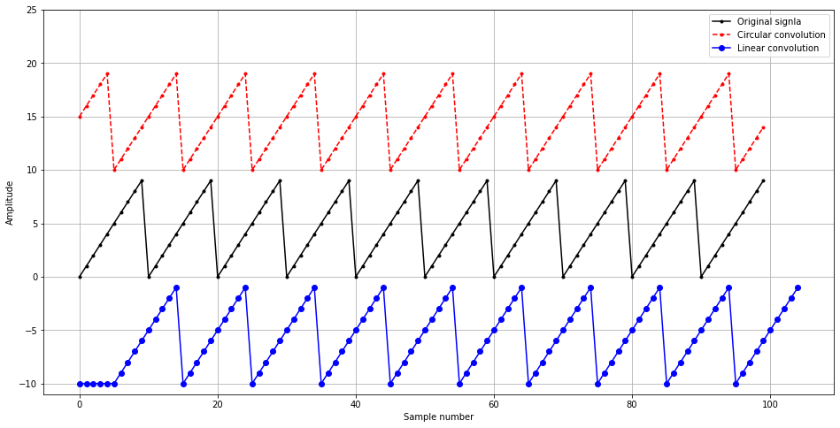

```python
# Create sawtooth signal
f = np.arange(0, 100, 1) % 10

# Create delay filter
g = np.array([0, 0, 0, 0, 0, 1])

# Compute linear convolution
y_l = linear_conv(f,g)

# Compute circular convolution
y_c = circular_conv(f, g)


plt.figure(figsize = (16,8))
plt.plot(f, "k.-", label="Original signla")
plt.plot(y_c + 10, "r.--", label="Circular convolution")
plt.plot(y_l - 10, "bo-", label="Linear convolution")

plt.xlabel('Sample number')
plt.ylabel('Amplitude')
plt.legend()
plt.ylim([-11, 25])
plt.grid()
plt.show()
```

## Questions

**Question**: How the result of circular convolution is different than the result of linear convolution?

# Fast discrete linear convolution

Implement fast linear convolution with circular convolution.

```python
def fast_linear_conv(f,g):
    K=f.size+g.size-1
    #F
    F=np.zeros(K)
    for i in range(K):
        if i<f.size:
            F[i]=f[i]

    #G
    G=np.zeros(K)
    for i in range(K):
        if i<g.size:
            G[i]=g[i]

    return circular_conv(F,G)

    """
    This function should calculate linear convolution of two signals in the frequency domain.

    Parameters
    ----------
    f: numpy array of shape (N, )
        Vector containing samples signal.
    g: numpy array of shape (M, )
        Vector containing samples of signal.

    Returns
    -------
    y: numpy array of shape (N+M-1,)
        Vetor containing convoluted signals.
    """
    raise NotImplementedError
```

## Verify you implementation.

```
RMSE: 2e-15
Your implementation succeeded
```

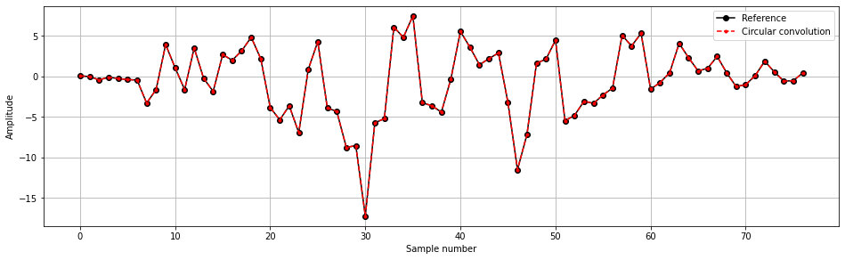

```python
# Do not change anything in the code below

# Generate signal f
f = np.random.randn(np.random.randint(10, 100))

# Generate signal g
g = np.random.randn(np.random.randint(10, 100))

# Compute convolution using your implementation
x = fast_linear_conv(f,g)

# Compute convolution using reference implementation from numpy
x_ref = np.convolve(f,g)

# Error between your implementation and reference implementation
x_err = np.abs(x - x_ref)**2

# RMSE
RMSE = np.sqrt(np.mean(x_err))

print('RMSE:', np.round(RMSE, 15))
print('Your implementation succeeded' if RMSE < 1e-10 else 'That RMSE is a little bit too BIG!')

plt.figure(figsize = (16,10))
plt.subplot(2,1,1)
plt.plot(x_ref, "ko-", label="Reference")
plt.plot(x, "r.--", label="Circular convolution")

plt.xlabel('Sample number')
plt.ylabel('Amplitude')
plt.legend()
plt.grid()
plt.show()
```

# Convolution performance (optional)

Compare performance of `np.convolve`, `linear_conv` and `fast_linear_conv` for random signals with varying size of signals `f` and `g`. Presents the results on the plot. Since function `linear_conv` is quit slow, do **not** test it using signals with length greater than 1024 samples.

```python
# Put your code here
```

# LTI difference equation

In general, by the impulse response, we can describe any LTI system. In practice, impulse response might be infinite and thus require a different processing approach for practical applications than convolution. Instead of using impulse responses, it is possible to exploit coefficients of the difference equation. The below difference equation describes an LTI system:

\begin{equation}\Large a_0 y[n] = \sum^{M}_{m=0} b_m x[n-m] - \sum^{K}_{k=1} a_k y[n-k] \end{equation}

where $a_i \in \mathbb{R}$ and $b_i \in \mathbb{R}$ are LTI system coefficients, $x[n]$ is a system input, and $y[n]$ is a system output. Notice that this formula resembles kind of two convolutions. The first one is with the input signal and the second one is with the output signal.

Write body of `LTI_filter` function which implements above differential equation.

```python
def LTI_filter(b, a, x):
    M=b.size
    K=a.size
    N=x.size

    y=np.zeros(N)

    for n in range(N):
        A=B=0
        for m in range(M):
            if (n-m>=0):
                B+=b[m]*x[n-m]
        for k in range(1,K):
            if (n-k>=0):
                A+=a[k]*y[n-k]
        y[n]=(B-A)/a[0]

    return y
    """

    Parameters
    ----------
    b: numpy array of shape (M, )
        A vector containing coefficients [b_0, b_1, ..., b_M].
    a: numpy array of shape (K, )
        A vector containing coefficients [a_0, a_1, ..., a_K].
    x: numpy array of shape (N, )
        A vector containing input signal.

    Returns
    -------
    y: numpy array of shape (N,)
        A vetor containing output signal
    """
    raise NotImplementedError
```

## Verify your implementation

```python
from scipy.signal import lfilter
```

```
RMSE: 2.359223927328458e-18
Your implementation succeeded
```

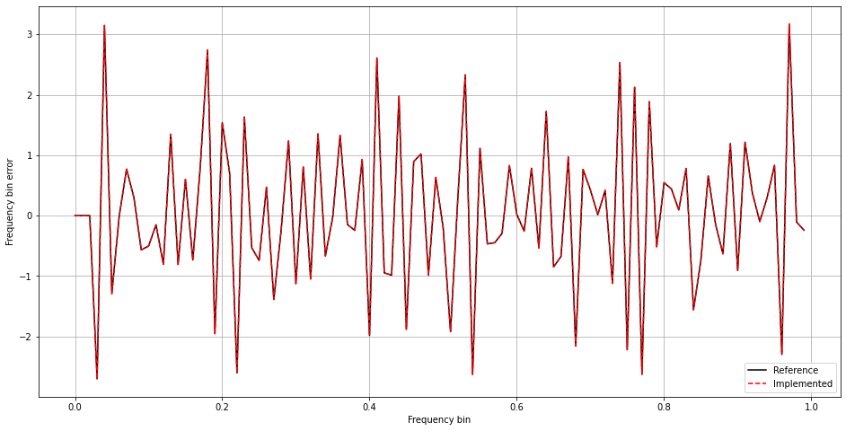

```python
fs = 1e2  # Sampling frequency
dt = 1/fs # Sampling interval
t_s = 0   # Start of sampling
t_e = 1   # End of sampling

# Generate timestamps of samples
t = np.arange(t_s, t_e, dt)

# Generate white noise signal as an test signal
x = np.random.randn(*t.shape)

b = np.array([0, 0, 0, 1])
a = np.array([1, 0.9, 0.4])

# Compute output using your implementation
y_f = LTI_filter(b, a, x)

# Reference implementation from scipy
y_f_ref = lfilter(b, a, x)

# Compute RMSE
y_RMSE = np.sqrt(np.mean(y_f - y_f_ref)**2)

print('RMSE:', y_RMSE)
print('Your implementation succeeded' if y_RMSE < 1e-16 else 'That RMSE is a little bit too BIG!')

fig, ax = plt.subplots(nrows=1, ncols=1, figsize=(16, 8))
ax.plot(t, y_f_ref, 'k-', label='Reference')
ax.plot(t, y_f, 'r--', label='Implemented')
plt.legend()
ax.set_ylabel('Frequency bin error')
ax.set_xlabel('Frequency bin')
plt.grid()
plt.show()
```

# Frequency response of LTI system

In this section, you will implement two appraoches to compute freqeuency response of LTI system.

## With time-limited (finite) impuse response

In the last notebook, you learned how to compute DFT, interpret it, and perform some operations on it. We can compute the frequency response of the LTI system by computing the DFT of an impulse response.

Implement function `LTI_impulse_freq` that computes frequency response from impulse response. Since we are operating only on real-valued signals, limit the frequency response only to positive frequencies. You might find function `np.fft.rfft` useful in this task.

```python
def LTI_impulse_freq(h, N=1024):


    H=np.fft.rfft(h,N)

    M=N//2 + 1
    freqs=np.zeros(M)

    for i in range(M):
        freqs[i]=i/M

    return freqs,H
    """

    Parameters
    ----------
    h: numpy array of shape (N, )
        Impulse response
    N: int
        Number of frequency bins in DFT

    Returns
    -------
    freqs: numpy array of shape (N % 2 + 1,)
        A vector containing normalized frequencies for each bin (only positive frequencies)
    H: numpy array of shape (N % 2 + 1,)
        A vector containing frequency response (only positive frequencies)
    """
    raise NotImplementedError
```

### Verify your implementation

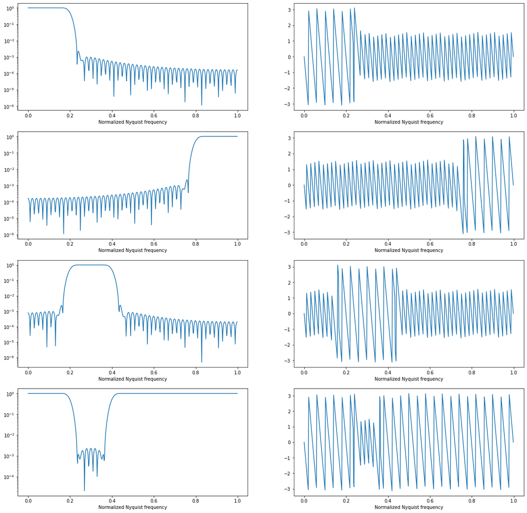

```python
# Import function for filter design
from scipy.signal import firwin

# Number of bins in frequency characteristic
N = 1024

# Low-pass filter with cut-off = 0.2 normalized Nyquist frequency
h_low_pass = firwin(101, 0.2)
freqs, H_low_pass = LTI_impulse_freq(h_low_pass, N=N)

# High-pass filter with cut-off = 0.2 normalized Nyquist frequency
h_high_pass = firwin(101, 0.8, pass_zero=False)
freqs, H_high_pass = LTI_impulse_freq(h_high_pass, N=N)

# Band-pass filter with band-pass = [0.2, 0.4] normalized Nyquist frequency
h_band_pass = firwin(101, [0.2, 0.4], pass_zero=False)
freqs, H_band_pass = LTI_impulse_freq(h_band_pass, N=N)

# Band-stop filter with band-stop = [0.2, 0.4] normalized Nyquist frequency
h_band_stop = firwin(101, [0.2, 0.4], pass_zero=True)
freqs, H_band_stop = LTI_impulse_freq(h_band_stop, N=N)


fig, axs = plt.subplots(nrows=4, ncols=2, figsize=(20,20))

axs[0, 0].semilogy(freqs, np.abs(H_low_pass))
axs[0, 0].set_xlabel("Normalized Nyquist frequency")
axs[0, 1].plot(freqs, np.angle(H_low_pass))
axs[0, 1].set_xlabel("Normalized Nyquist frequency")

axs[1, 0].semilogy(freqs, np.abs(H_high_pass))
axs[1, 0].set_xlabel("Normalized Nyquist frequency")
axs[1, 1].plot(freqs, np.angle(H_high_pass))
axs[1, 1].set_xlabel("Normalized Nyquist frequency")

axs[2, 0].semilogy(freqs, np.abs(H_band_pass))
axs[2, 0].set_xlabel("Normalized Nyquist frequency")
axs[2, 1].plot(freqs, np.angle(H_band_pass))
axs[2, 1].set_xlabel("Normalized Nyquist frequency")

axs[3, 0].semilogy(freqs, np.abs(H_band_stop))
axs[3, 0].set_xlabel("Normalized Nyquist frequency")
axs[3, 1].plot(freqs, np.angle(H_band_stop))
axs[3, 1].set_xlabel("Normalized Nyquist frequency")

plt.show()
```

## General appraoch

Previous appraoch applies only to time-limited impulse respones. If the impulse response is infinite, we must use system transfer function $H(z)$, given as \begin{equation}\Large H(z) = \frac{\sum_{m=0}^{M} b_m z^{-m}}{\sum_{l=0}^{L} a_l z^{-l}}, \end{equation} where $a_l \in \mathbb{R}$ and $b_i \in \mathbb{R}$ are LTI system coefficients. By using following substitution $\large z = e^{j 2\pi f}$, we can compute frequency response of any LTI system.

Implement function `LTI_freqz` that compute frequency response of a discrete-time LTI system on first half of unit circle (only positive frequencies).

```python
def LTI_freqz(b, a, N=1024):

    M=b.size
    L=a.size
    K=N//2 + 1

    freqs=np.zeros(N)
    z=H=np.zeros(N,dtype=complex)

    for i in range(N):
        freqs[i]=i/N
        z[i]=np.exp(2j*np.pi*freqs[i])

    for i in range(N):
        A=B=0
        for m in range(M):
            B+=b[m]*(z[i]**(-m))
        for l in range(L):
            A+=a[l]*(z[i]**(-l))

        H[i]=B/A

    freqs=freqs[:K]
    H=H[:K]
    return freqs,H

    """

    Parameters
    ----------
    b: numpy array of shape (M, )
        A vector containing coefficients [b_0, b_1, ..., b_M] of H(z) numerator.
    a: numpy array of shape (L, )
        A vector containing coefficients [a_0, a_1, ..., a_L] of H(z) denumerator.
    N: int
        Number of discrete points on unit circle

    Returns
    -------
    freqs: numpy array of shape (N % 2 + 1,)
        A vector containing normalized (to Nyqist frequency) frequencies for each bin (only positive frequencies)
    H: numpy array of shape (N % 2 + 1,)
        A vector containing frequency response (only positive frequencies)
    """
    raise NotImplementedError
```

### Verify your implementation

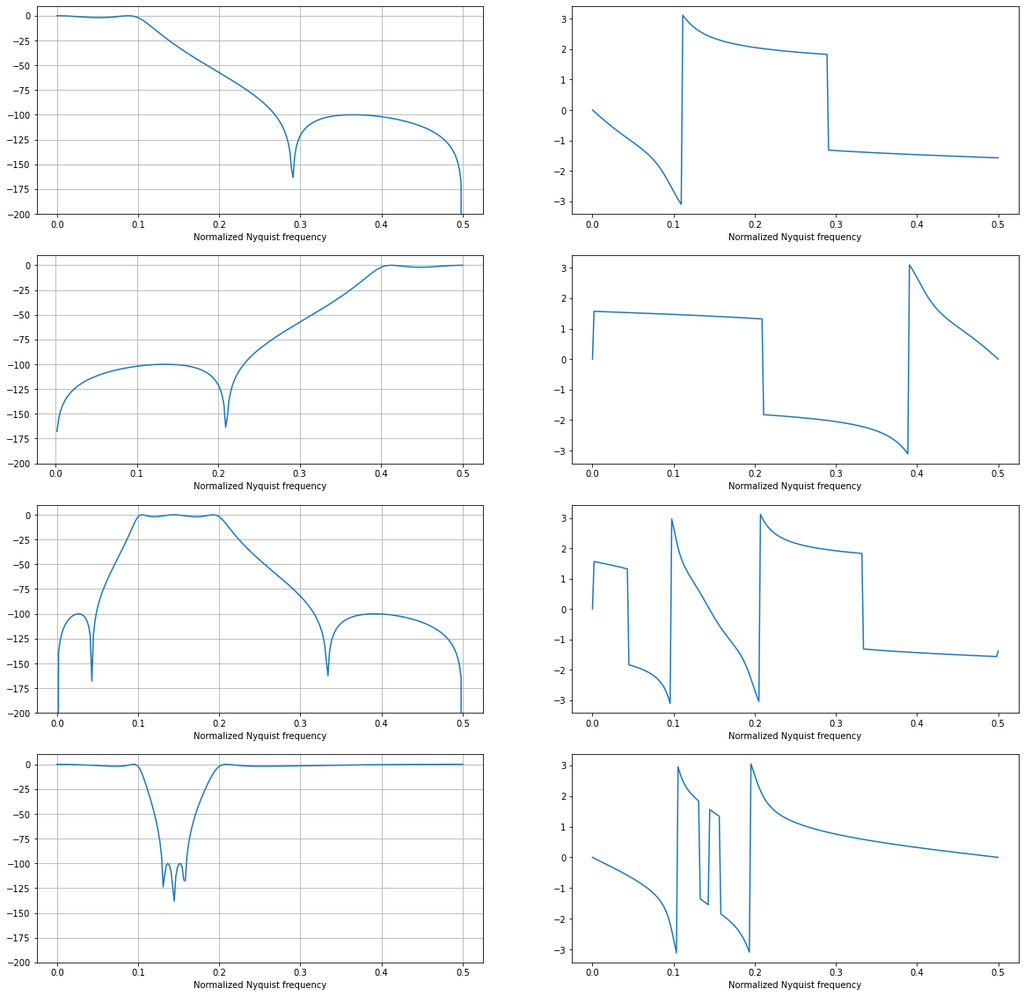

```python
# Import function for filter design
from scipy.signal import ellip

# Number of bins in frequency characteristic
N = 512

# Low-pass filter with cut-off = 0.2 normalized Nyquist frequency
b, a = ellip(3, 1, 50, 0.2)
freq, H_low_pass = LTI_freqz(b, a, N=N)

# # High-pass filter with cut-off = 0.2 normalized Nyquist frequency
b, a = ellip(3, 1, 50, 0.8, btype='high')
freq, H_high_pass = LTI_freqz(b, a, N=N)

# # Band-pass filter with band-pass = [0.2, 0.4] normalized Nyquist frequency
b, a = ellip(3, 1, 50, [0.2, 0.4], btype='bandpass')
freq, H_band_pass = LTI_freqz(b, a, N=N)

# Band-stop filter with band-stop = [0.2, 0.4] normalized Nyquist frequency
b, a = ellip(3, 1, 50, [0.2, 0.4], btype='bandstop')
freq, H_band_stop = LTI_freqz(b, a, N=N)


fig, axs = plt.subplots(nrows=4, ncols=2, figsize=(20,20))

rb, rt = -200, 10
axs[0, 0].plot(freq, 20*np.log10(np.abs(H_low_pass)**2))
axs[0, 0].set_xlabel("Normalized Nyquist frequency")
axs[0, 0].set_ylim([rb, rt])
axs[0, 0].grid()
axs[0, 1].plot(freq, np.angle(H_low_pass))
axs[0, 1].set_xlabel("Normalized Nyquist frequency")

axs[1, 0].plot(freq, 20*np.log10(np.abs(H_high_pass)**2))
axs[1, 0].set_xlabel("Normalized Nyquist frequency")
axs[1, 0].set_ylim([rb, rt])
axs[1, 0].grid()
axs[1, 1].plot(freq, np.angle(H_high_pass))
axs[1, 1].set_xlabel("Normalized Nyquist frequency")

axs[2, 0].plot(freq, 20*np.log10(np.abs(H_band_pass)**2))
axs[2, 0].set_xlabel("Normalized Nyquist frequency")
axs[2, 0].set_ylim([rb, rt])
axs[2, 0].grid()
axs[2, 1].plot(freq, np.angle(H_band_pass))
axs[2, 1].set_xlabel("Normalized Nyquist frequency")

axs[3, 0].plot(freq, 20*np.log10(np.abs(H_band_stop)**2))
axs[3, 0].set_xlabel("Normalized Nyquist frequency")
axs[3, 0].set_ylim([rb, rt])
axs[3, 0].grid()
axs[3, 1].plot(freq, np.angle(H_band_stop))
axs[3, 1].set_xlabel("Normalized Nyquist frequency")

plt.show()
```

# Stability in LTI system

The instability of the LTI system can occur in two cases. The first one is the instability of the system which is caused by system design. The second one is numerical instability.

## BIBO stability

[Bounded-input, bounded-output stability (BIBO)](https://en.wikipedia.org/wiki/BIBO_stability) is a condition that any stable LTI system must meet. Let's design a few simple LTI systems with a feedback loop and check their output. The code changes the feedback coefficient.

Investigate code and results.

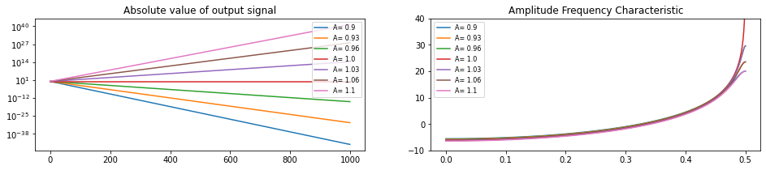

```python
fig, axs = plt.subplots(nrows=1, ncols=2, figsize=(16, 3))

for A in np.linspace(0.9, 1.1, 7):

    b = np.array([1])
    a = np.array([1, A])

    freq, H = LTI_freqz(b, a)

    # Create Kronecker delta
    x = np.zeros(1000)
    x[0] = 1

    # Filter signal
    y = LTI_filter(b, a, x)

    # Show output signal
    axs[0].semilogy(np.abs(y), label="A= "+str(A)[:4])
    axs[1].plot(freq, 20*np.log10(np.abs(H)), label="A= "+str(A)[:4])

axs[0].set_title("Absolute value of output signal")
axs[1].set_title("Amplitude Frequency Characteristic")
axs[0].legend(fontsize=8)
axs[1].legend(fontsize=8)
axs[1].set_ylim([-10, 40])
plt.show()
```

## Questions

**Question**: For what values of paramters `A` system is unstable?

**Question**: Why check BIBO stability with Kronecker delta as input signal?

**Question**: Why can't we just check poles of the system in general?

## Check stability

Implement a simple function that checks BIBO stability of the LTI system. Next, write a script that demonstrates that your implementation of function `BIBO_stability` works correctly for a few simple cases.

**Hint**: The function should monitor energy of the function in time.

```python
def BIBO_stability(b, a):
    """
    Parameters
    ----------
    b: numpy array of shape (M, )
        A vector containing coefficients [b_0, b_1, ..., b_M] of H(z) numerator.
    a: numpy array of shape (K, )
        A vector containing coefficients [a_0, a_1, ..., a_K] of H(z) denumerator.

    Returns
    -------
    stable: bool
        `True` if system is stable, otherwise `False`
    """

    raise NotImplementedError
```

```python
# Write verification script
```

## Numerical instability (optional)

The second kind of LTI system instability is numerical stability caused by finite floating-point precision. Let's consider below system with high-order Chebyshev type II filter.

```python
from scipy.signal import cheby2

# Low-pass filter; 30th order Chebyshev type II
b, a = cheby2(30, 180, 0.2)

freq, H = LTI_freqz(b, a)

# Create Kronecker delta
x = np.zeros(1000)
x[0] = 1

# Filter signal
y = LTI_filter(b, a, x)

# Show output signal
fig, axs = plt.subplots(nrows=1, ncols=2, figsize=(16, 3))
axs[0].plot(y)
axs[0].set_title("System output")
axs[1].plot(freq, 20*np.log10(np.abs(H)))
axs[1].set_title("Amplitude Frequency Characteristic")
plt.show()
```

[output not shown]

Despite the system is stable by design, its output is not bounded. It's due to the finite precision of the LTI system coefficients.

### Second-Order Sections

Since $H(z)$ is a [rational function](https://en.wikipedia.org/wiki/Rational_function), we can make a [partial fraction decomposition](https://en.wikipedia.org/wiki/Partial_fraction_decomposition) and rewrite it to following form \begin{equation}\Large H(z) = \prod_{p=1}^{P} \frac{\sum_{m=0}^{2} b^{(p)}_m z^{-m}}{\sum_{l=0}^{2} b^{(p)}_l z^{-l}}, \end{equation} where $P$ is number of sections, $b^{(p)}_m \in \mathbb{R}$ and $a^{(p)}_k \in \mathbb{R}$ are second-order coefficients of $p$-th section. Note that $p$ in $b^{(p)}_m$ is the index of the second-order section, not index of the exponential funtion $a^p$.

```python
def SOS_LTI_filter(sos, x):
    """

    Parameters
    ----------
    sos: numpy array of shape (P, 6)
        Second-order filter coefficients where `sos[p,:] = [b^p_0, b^p_1, b^p_2, a^p_0, a^p_1, a^p_2]`
    x: numpy array of shape (N, )
        A vector containing input signal.

    Returns
    -------
    y: numpy array of shape (N,)
        A vetor containing output signal
    """
    raise NotImplementedError
```

### Verify

```python
# Design a filter
b, a = ellip(3, 1, 50, 0.2)

# Design a filter with SOS
sos = ellip(3, 1, 50, 0.2, output='sos')

# Create Kronecker delta
x = np.zeros(100)
x[0] = 1

# Filter signal
y = LTI_filter(b, a, x)

# Filter signal using SOS
y_sos = SOS_LTI_filter(sos, x)

# Compute RMSE
RMSE = np.sqrt(np.mean(y - y_sos)**2)

print('RMSE:', RMSE)
print('Your implementation succeeded' if RMSE < 1e-14 else 'That RMSE is a little bit too BIG!')

plt.plot(y, 'k-', label="LTI_filter")
plt.plot(y_sos, 'r.-', label="SOS_LTI_filter")
plt.legend()
plt.show()
```

### System with numerical instability using SOS

Now let's design exactl same filter with numerical unstability but filter signal uinsg second-order sections.

```python
# Low-pass filter; 30th order Chebyshev type II; Second-Order Sections
b, a = cheby2(30, 150, 0.2)

# Low-pass filter; 30th order Chebyshev type II; Second-Order Sections
sos = cheby2(30, 150, 0.2, output="sos")

# Create Kronecker delta
x = np.zeros(350)
x[0] = 1


# Filter signal
y = LTI_filter(b, a, x)

# Filter signal using SOS
y_sos = SOS_LTI_filter(sos, x)

# Show output signal
plt.plot(y, label="LTI_filter")
plt.plot(y_sos, label="SOS_LTI_filter")
plt.legend()
plt.grid()
plt.show()
```